# Bericht 3

Daniela Palleschi

Humboldt-Universität zu Berlin

2024-07-09

# Bericht 3

> The purpose of this report is to consolidate what we have learned over the last few weeks with what we have learned previously. You will load a dataset from a published paper that investigates voiced-onset times (Sonderegger, 2023) that is available on Moodle. If you are not enrolled in this course on Moodle, the dataset is also freely available on the Open Science Framework at https://osf.io/cmh3p.

> You can create your own Quarto script from scratch or use a blank script I created with the questions and corresponding headings. You can find this script on Moodle or online [here](https://github.com/daniela-palleschi/r4ling/blob/689c46b15a883d0fb2d001ea50d97fa101e23d62/slides/11-bericht2/empty%20script/student_bericht2.qmd).

# Set-up

> This report is shared with you as an incomplete Quarto script. Your task is to follow the instructions to complete the script. The instructions are preceded by a `>`, in order to differentiate them from your own text that you will include to describe your data. Please keep the instructions in the script so that it is clear what each task is trying to achieve. You may delete this paragraph if you wise.

## Render

> Before continuing, check that you can render the script as PDF. It should run even though below there are incomplete code chunks, because the YAML includes `eval: false`.

## YAML

> Change the YAML so that:
> - `eval: true`
> - `author: "YOUR NAME"`

> Now you will not be able to render the document until all the code chunks below are completed, because there are incomplete code chunks below and you have set `eval: true`.

## Packages

> Load in the packages `tidyverse`, `gghalves`, `patchwork`, and `here`.

## Load data

> Below is a code chunk that loads in a data set from Sonderegger et al. (2017) and discussed in Sonderegger (2023). **Wichtig:** Sie müssen die Daten bereits heruntergeladen haben, entweder von Moodle oder vom [Open Science Framework](https://osf.io/cmh3p), und sie in Ihrem ‘daten’-Ordner gespeichert haben.

```
Copy and run this code
```

```r
df_vot <-
  read_csv(here::here("daten", "vot_rmld_2023.csv"))
```

## Data exploration

> Explore the dataset however you like to get familiar with it. You do not need to show your work for this task, but if you do please keep in mind that if you use code in the script that prints the data (e.g., running simply `df_vot`), it will produce all the rows (n = 25154) when you render the document, adding many pages to your rendered document. For this reason, try using `head()` to print only the first 6 rows (first discussed in [Chatper 4](https://daniela-palleschi.github.io/r4ling/mats/04-wrangling_1.html#lexdec)), or simply opening the dataset viewer by double clicking on its name in the ‘Environment’ pane.

# Base R

> In this section you will interpret and write code in base R and/or the tidyverse.

## Filter

> Using base R, filter the data to only include the speakers `rex`, `michael`, `sara`, and `lisa.` Tip: you will want to use `[,]`, where rows are defined on the left and columns on the right. We want all columns, so you don’t need to include anything to the right of the comma.

```
Complete this code
```

```r
df_vot <-
  ...
```

## Code description

> Describe in words what the following base R code achieves:

```r
df_vot[df_vot$vot > 75 & df_vot$voicing == "voiced", 1]
```

## base R-tidyverse ‘translation’

> Now write the same code in tidyverse and print the result.

```
Complete this code
```

```r
df_vot |>
  ...
```

## base R summary

> Using base R, create a summary called `sum_vot` which contains the mean and standard deviation voice onset times, and number of observations (using `length()`) of the whole dataset.

```
Complete this code
```

```r
sum_vot <-
  ...
```

## Tidyverse summary

> Now, using the tidyverse, do the same but produce these values by speaker, phone, place, and voicing. Call it `sum_speaker`.

```
Complete this code
```

```r
sum_speaker <-
  ...
```

# Plots

> For these tasks you will produce two plots using functions and arguments covered in the Data Visualisation 4 session.

## Multi-part plot

```
Complete this code
```

```r
fig_vot <-
  ...
```

## Errorbar plot

```
Complete this code
```

```r
fig_vot_error <-
  ...
```

## Print plots

> Print your plots one on top of the other using the `patchwork` package. Include the labels `A` and `B` (we saw how to do this twice: in [Chapter 10](https://daniela-palleschi.github.io/r4ling/mats/10-dataviz_3.html#patchwork) and [Chapter 13](https://daniela-palleschi.github.io/r4ling/mats/10-dataviz_3.html#patchwork)). They should look something like Abbildung 1 A and B.

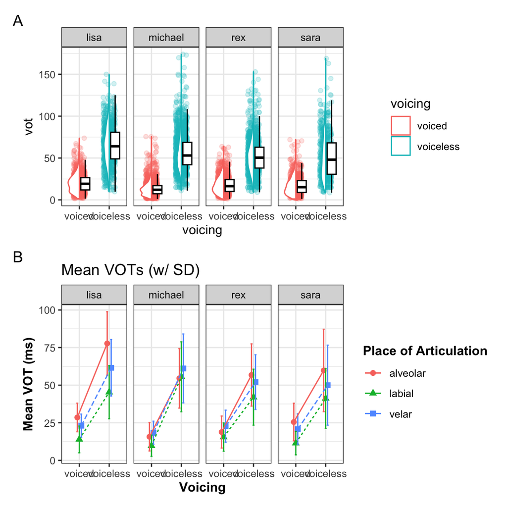

Abbildung 1: Reproduce this plot.

## Plot interpretation

> Interpret your plots. Consider the differences between speakers, voicing, and of place of articulation (and if any of these differences varied as a function of another variable, e.g., are the differences of voicing and place of articulation the same for all speakers?).

# Reflection

> Reflect on your journey through this course. What did you find particularly interesting? What was difficult? What do you still struggle with? Do you see yourself applying what you’ve learned in future work? How might the course be improved moving forward?

# References

Woche 10 - Datenvisualisierung 3

Sonderegger, M. (2023). *Regression Modeling for Linguistic Data*.

Sonderegger, M., Bane, M., & Graff, P. (2017). The Medium-Term Dynamics of Accents on Reality Television. *Language*, *93*(3), 598–640. https://doi.org/10.1353/lan.2017.0038